# How to improve your viz in R with less

## Background

- working for Allianz Technology since 5 years as head of a small AI team
- working with **R**
- building dashboards with **Shiny**
- giving presentations to management and talks on conferences
- like to work with ML, AI, Big Data,…
- **viz enthusiast**

Better to learn **one** programming language **good** (in deep) then to know just a **little** in **many** programming languages.  
=> today just **R**

## Intention of this talk

How can I improve my viz although I have no time for it?

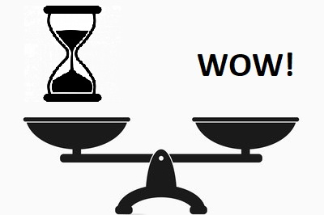

## Intention of this talk II

- Think about the **intention** first
- What is **important**?
  - A single number
  - Comparison of several numbers
  - whole time series
  - relative or absolute numbers
- Make small improvements to your viz
- Step-by-step improvements

I will present a collection of **Tips and Tricks** I found myself or in blog posts, stack overflow, conferences ,…

## Tip 0: Get inspired

## Get inspired

The R Graph Gallery: https://www.r-graph-gallery.com/

Top 50 ggplot2 Visualizations - The Master List: http://r-statistics.co/Top50-Ggplot2-Visualizations-MasterList-R-Code.html

R-bloggers: https://www.r-bloggers.com/

Stack overflow https://stackoverflow.com/questions/tagged/r+plot

[figure not shown]

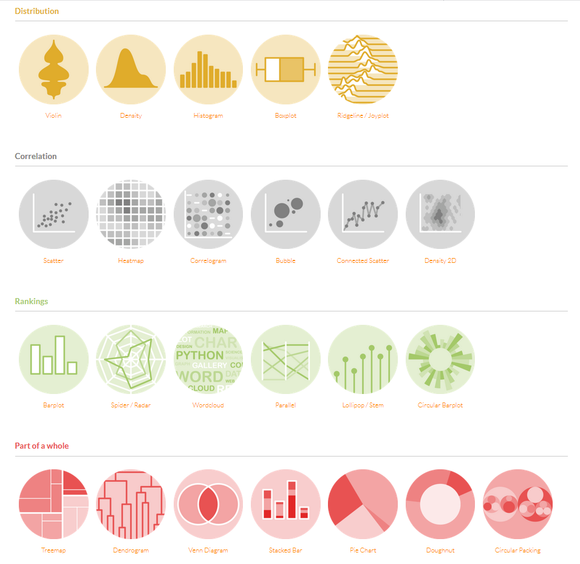

```r
tip <- 1
```

## Tip 1: Highlighting rows and columns in tables

### Highlighting rows and columns in tables

```r
library(DT)
DT::datatable(iris, options = list(pageLength = 5))
```

|  | Sepal.Length | Sepal.Width | Petal.Length | Petal.Width | Species |
| --- | --- | --- | --- | --- | --- |
| 1 | 5.1 | 3.5 | 1.4 | 0.2 | setosa |
| 2 | 4.9 | 3 | 1.4 | 0.2 | setosa |
| 3 | 4.7 | 3.2 | 1.3 | 0.2 | setosa |
| 4 | 4.6 | 3.1 | 1.5 | 0.2 | setosa |
| 5 | 5 | 3.6 | 1.4 | 0.2 | setosa |
| 6 | 5.4 | 3.9 | 1.7 | 0.4 | setosa |
| 7 | 4.6 | 3.4 | 1.4 | 0.3 | setosa |
| 8 | 5 | 3.4 | 1.5 | 0.2 | setosa |
| 9 | 4.4 | 2.9 | 1.4 | 0.2 | setosa |
| 10 | 4.9 | 3.1 | 1.5 | 0.1 | setosa |

[output cut: 140 more lines]

### Highlighting rows and columns in tables

```r
datatable(iris, options = list(pageLength = 5)) %>%
  formatStyle('Sepal.Length', fontWeight = styleInterval(5, c('normal', 'bold')))
```

|  | Sepal.Length | Sepal.Width | Petal.Length | Petal.Width | Species |
| --- | --- | --- | --- | --- | --- |
| 1 | 5.1 | 3.5 | 1.4 | 0.2 | setosa |
| 2 | 4.9 | 3 | 1.4 | 0.2 | setosa |
| 3 | 4.7 | 3.2 | 1.3 | 0.2 | setosa |
| 4 | 4.6 | 3.1 | 1.5 | 0.2 | setosa |
| 5 | 5 | 3.6 | 1.4 | 0.2 | setosa |
| 6 | 5.4 | 3.9 | 1.7 | 0.4 | setosa |
| 7 | 4.6 | 3.4 | 1.4 | 0.3 | setosa |
| 8 | 5 | 3.4 | 1.5 | 0.2 | setosa |
| 9 | 4.4 | 2.9 | 1.4 | 0.2 | setosa |
| 10 | 4.9 | 3.1 | 1.5 | 0.1 | setosa |

[output cut: 140 more lines]

### Highlighting rows and columns in tables

|  | Sepal.Length | Sepal.Width | Petal.Length | Petal.Width | Species |
| --- | --- | --- | --- | --- | --- |
| 1 | 5.1 | 3.5 | 1.4 | 0.2 | setosa |
| 2 | 4.9 | 3 | 1.4 | 0.2 | setosa |
| 3 | 4.7 | 3.2 | 1.3 | 0.2 | setosa |
| 4 | 4.6 | 3.1 | 1.5 | 0.2 | setosa |
| 5 | 5 | 3.6 | 1.4 | 0.2 | setosa |
| 6 | 5.4 | 3.9 | 1.7 | 0.4 | setosa |
| 7 | 4.6 | 3.4 | 1.4 | 0.3 | setosa |
| 8 | 5 | 3.4 | 1.5 | 0.2 | setosa |
| 9 | 4.4 | 2.9 | 1.4 | 0.2 | setosa |
| 10 | 4.9 | 3.1 | 1.5 | 0.1 | setosa |

[output cut: 140 more lines]

### Highlighting rows and columns in tables

```r
datatable(iris) %>%
  formatStyle('Sepal.Length', fontWeight = styleInterval(5, c('normal', 'bold'))) %>%
  formatStyle(
    'Sepal.Width',
    color = styleInterval(c(3.4, 3.8), c('white', 'blue', 'red')),
    backgroundColor = styleInterval(3.4, c('gray', 'yellow'))
  )
```

### Highlighting rows and columns in tables

|  | Sepal.Length | Sepal.Width | Petal.Length | Petal.Width | Species |
| --- | --- | --- | --- | --- | --- |
| 1 | 5.1 | 3.5 | 1.4 | 0.2 | setosa |
| 2 | 4.9 | 3 | 1.4 | 0.2 | setosa |
| 3 | 4.7 | 3.2 | 1.3 | 0.2 | setosa |
| 4 | 4.6 | 3.1 | 1.5 | 0.2 | setosa |
| 5 | 5 | 3.6 | 1.4 | 0.2 | setosa |
| 6 | 5.4 | 3.9 | 1.7 | 0.4 | setosa |
| 7 | 4.6 | 3.4 | 1.4 | 0.3 | setosa |
| 8 | 5 | 3.4 | 1.5 | 0.2 | setosa |
| 9 | 4.4 | 2.9 | 1.4 | 0.2 | setosa |
| 10 | 4.9 | 3.1 | 1.5 | 0.1 | setosa |

[output cut: 140 more lines]

### Highlighting rows and columns in tables

```r
datatable(iris) %>%
  formatStyle(
    'Petal.Length',
    background = styleColorBar(iris$Petal.Length, 'steelblue'),
    backgroundSize = '100% 90%',
    backgroundRepeat = 'no-repeat',
    backgroundPosition = 'center'
  )
```

## Tip 2: Formatting columns in tables

### Formatting columns in tables

```r
m = cbind(matrix(rnorm(60, 1e4, 1e5), 20), runif(20), rnorm(20, 100))
m[, 1:3] = round(m[, 1:3])
m[, 4:5] = round(m[, 4:5], 5)
colnames(m) = head(LETTERS, ncol(m))
head(m)
```

```
##            A      B      C       D         E
## [1,]   10531 150745 147805 0.54364 100.47876
## [2,]   27848 -22440 116784 0.53276  99.69036
## [3,]  -10612  70632 -15194 0.30657 100.26557
## [4,]   27155  32797  -4507 0.78993  98.55043
## [5,] -153400 236934  26178 0.99803  99.71932
## [6,]   92186 145155 -96389 0.29309 100.98859
```

### Formatting columns in tables

| A | B | C | D | E |
| --- | --- | --- | --- | --- |
| 10531 | 150745 | 147805 | 0.54364 | 100.47876 |
| 27848 | -22440 | 116784 | 0.53276 | 99.69036 |
| -10612 | 70632 | -15194 | 0.30657 | 100.26557 |
| 27155 | 32797 | -4507 | 0.78993 | 98.55043 |
| -153400 | 236934 | 26178 | 0.99803 | 99.71932 |
| 92186 | 145155 | -96389 | 0.29309 | 100.98859 |
| -92308 | 26651 | 38625 | 0.29046 | 102.3408 |
| -88584 | 33472 | -36622 | 0.04605 | 99.76239 |
| 4696 | -17140 | -109871 | 0.86052 | 100.872 |
| -36314 | 186552 | -11370 | 0.97472 | 98.83689 |

[output cut: 10 more lines]

### Formatting of DT

- use functions `formatStyle(), formatCurrency(), formatPercentage(), formatDate()`
- bold, italic, font size, font color
- background color, “bar chart”
- row names, col names, table header

```r
# format the columns A and C as currency, and D as percentages
datatable(m) %>% formatCurrency(c('A', 'C')) %>% formatPercentage('D', 2)

# the first two columns are Euro currency, and round column E to 3 decimal places
datatable(m) %>% formatCurrency(1:2, '\U20AC', digits = 0) %>% formatRound('E', 3)
```

https://rstudio.github.io/DT/functions.html

## Tip 3: Highlighting rows and columns in tables #2

### Package: formattable

Example:

| Indicator Name | 2011 | 2012 | 2013 | 2014 | 2015 | 2016 | Average | Improvement |
| --- | --- | --- | --- | --- | --- | --- | --- | --- |
| Prevalence of Obesity | 19.1 | 23.6 | 23.3 | 20.5 | 24.0 | 23.2 | 22.28 | -21.47 |
| Prevalence of Tobacco Use | 17.4 | 15.0 | 15.3 | 12.2 | 16.6 | 16.7 | 15.53 | 4.02 |
| Prevalence of Cardiovascular Disease | 5.0 | 4.9 | 1.5 | 4.4 | 4.9 | 6.2 | 4.48 | -24 |
| Prevalence of Diabetes | 8.0 | 7.2 | 9.3 | 7.2 | 7.5 | 10.4 | 8.27 | -30 |

### Package: formattable

Most important function: `formatter("span", style = ~ style(...))`

- Column alignment (argument `align`)
- formatting with `percent(), currency(), comma(), ...`
- Use color `color_bar(), color_text(), color_tile()`
- Add icons `icontext()`
- and much more

https://www.r-bloggers.com/create-stylish-tables-in-r-using-formattable/amp/

https://www.r-bloggers.com/make-beautiful-tables-with-the-formattable-package/amp/

### Package: formattable

Sometimes it is useful to use arrows to show statistical significance. While formattable is not super flexible in this regard, it can do a good job nonetheless.

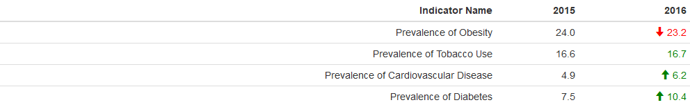

Which icons are possible: see [Glyphicons in Bootstrap](https://getbootstrap.com/docs/3.3/components/), [Glyphicons](https://www.glyphicons.com/)

```r
icontext("plus")
icontext(c("star","star-empty"))
```

### Package: formattable

The sparklines package can be used to create spark-lines.  
The way that we do this is by converting the spark line into text `(character(htmltools::as.tags)`, and then telling the formattable HTML widget that it also contains spark lines.

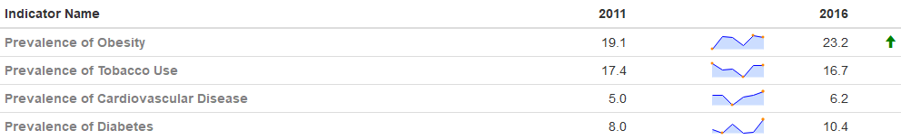

```r
prevalence$`2012` = apply(prevalence[, 2:7], 1, FUN = function(x)
  as.character(htmltools::as.tags(sparkline(as.numeric(x), type = "line"))))
```

Possible spark lines: bar, line, bullet, pie, tristate and discrete

### Package: formattable - Little trick for Rmarkdown

```r
# Export a Formattable as PNG, PDF, or JPEG

library(htmltools)
library(webshot)

export_formattable <- function(f, file, width = "100%", height = NULL,
                               background = "white", delay = 0.2){
  w <- as.htmlwidget(f, width = width, height = height)
  path <- html_print(w, background = background, viewer = NULL)
  url <- paste0("file:///", gsub("\\\\", "/", normalizePath(path)))
  webshot(url, file = file,
          selector = ".formattable_widget",
          delay = delay)
}
```

https://stackoverflow.com/questions/34983822/how-to-have-r-formattable-rendered-to-pdf-output-and-how-to-have-percents-in-the

## Tip 4: Paper ready tables

### Paper ready tables

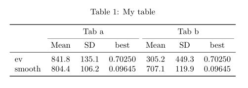

https://stackoverflow.com/questions/44324042/r-xtable-with-multicolumns-and-booktabs  
http://haozhu233.github.io/kableExtra/awesome_table_in_pdf.pdf

Similar: http://cameron.bracken.bz/sweave-xtable-booktabs

### Paper ready tables

```r
library(kableExtra)
options(knitr.table.format = "latex")

dat <- structure(c(841.8, 804.4, 135.1, 106.2, 0.7025, 0.09645, 305.2,
707.1, 449.3, 119.9, 0.7025, 0.09645),
.Dim = c(2L, 6L),
.Dimnames = list(c("ev", "smooth"),
                 c("Mean", "SD", "best", "Mean", "SD", "best"))
)

kable(dat, booktabs = TRUE, caption = "My table", align = "c") %>%
  add_header_above(c(" ", "Tab a" = 3, "Tab b" = 3)) %>%
    kable_styling(latex_options = "hold_position")
```

## Tip 5: Label line ends in time series with ggplot2

### Label line ends in time series with ggplot2

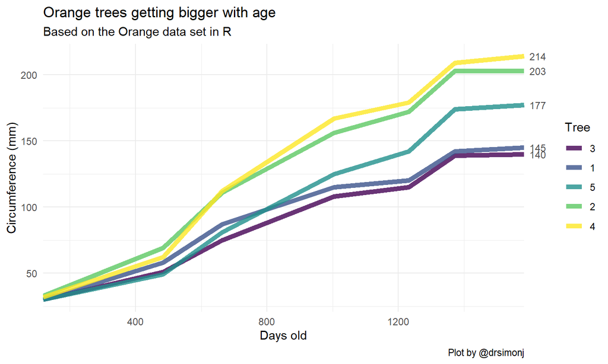

Package: `ggplot2`  
Function: `scale_y_continuous(sec.axis = sec_axis(...))`  
https://www.r-bloggers.com/label-line-ends-in-time-series-with-ggplot2/

## Tip 6: Annotations in plots

### Annotations in plots

In general annotations in plots are no difficult task to do in R.  
In **base** plots it is `text()` or `mtext()` and in **ggplot2** `geom_text()`.  
So far so good. But with **ggplot2** we can have multiple plots with facets (`facet_grid()`). What if we want different annotations in each plot?

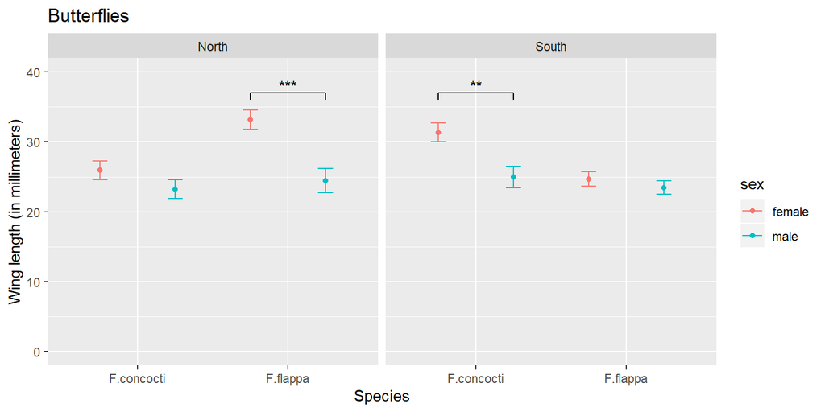

### Adding different annotation to each facet in ggplot

I guess it is quite easy to get something like this:

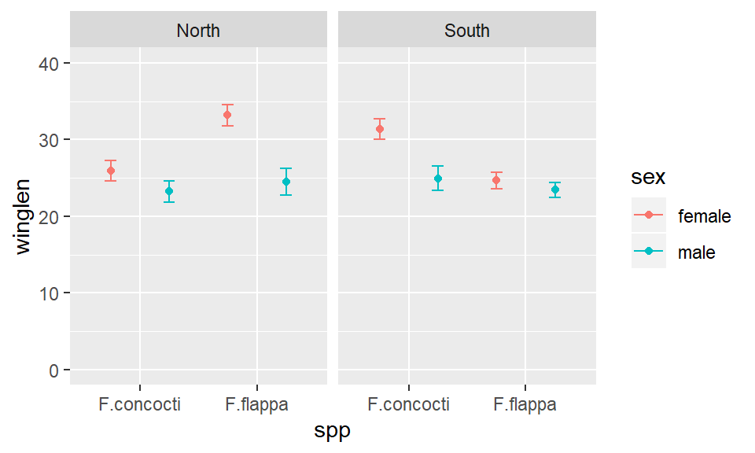

```r
ggplot(data=buttersum, aes(x=spp, y=winglen)) +
  geom_point(aes(colour=sex), position = position_dodge(width = 1)) +
  geom_errorbar(aes(colour=sex, ymin=winglen-se, ymax=winglen+se),
                width = .2, position = position_dodge(width = 1)) +
  ylim(0, 40) + facet_grid(. ~ region)
```

### Adding different annotation to each facet in ggplot

The easiest way to annotate for each facet separately is to create a data-frame with a row for each facet:

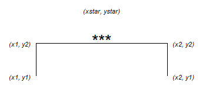

```r
anno <- data.frame(x1 = c(1.75, 0.75), x2 = c(2.25, 1.25),
                   y1 = c(36, 36), y2 = c(37, 37),
                   xstar = c(2, 1), ystar = c(38, 38),
                   lab = c("***", "**"),
                   region = c("North", "South"))
```

### Adding different annotation to each facet in ggplot

And then add the annotation to the plot:

```r
ggplot(data = buttersum, aes(x = spp, y = winglen)) +
  geom_point(aes(colour=sex), position = position_dodge(width=1)) +
  geom_errorbar(aes(colour=sex, ymin=winglen-se, ymax=winglen+se),
                width = .2, position = position_dodge(width = 1)) +
  ylim(0, 40) +
  geom_text(data = anno, aes(x = xstar,  y = ystar, label = lab)) +
  geom_segment(data = anno, aes(x = x1, xend = x1, y = y1, yend = y2),
           colour = "black") +
  geom_segment(data = anno, aes(x = x2, xend = x2, y = y1, yend = y2),
           colour = "black") +
  geom_segment(data = anno, aes(x = x1, xend = x2, y = y2, yend = y2),
           colour = "black")+
  facet_grid(. ~ region) +
  ggtitle("Butterflies") +
  xlab("Species") + ylab("Wing length (in millimeters)")
```

From https://www.r-bloggers.com/adding-different-annotation-to-each-facet-in-ggplot/

## Tip 7: Removing weekends from line graphs

### Removing weekends from line graphs

**Problem:** Given a data set with values for each day but not for the weekends (or public holiday).  
Usually we plot such data with `Date` on the x-axes and some numerical value on the y-axes, but having some nasty “holes” in our bar or line plot.

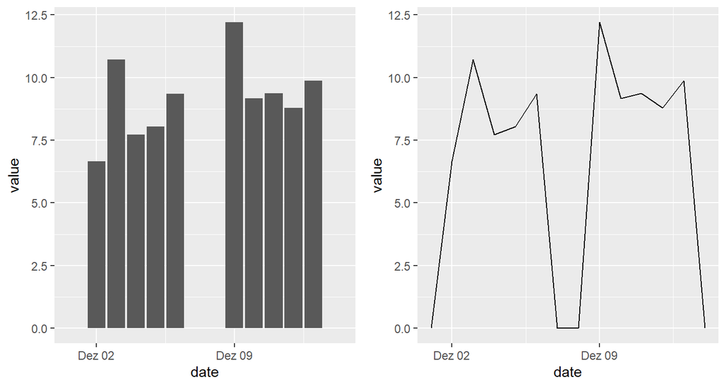

### Removing weekends from line graphs

Removing the rows with no values:

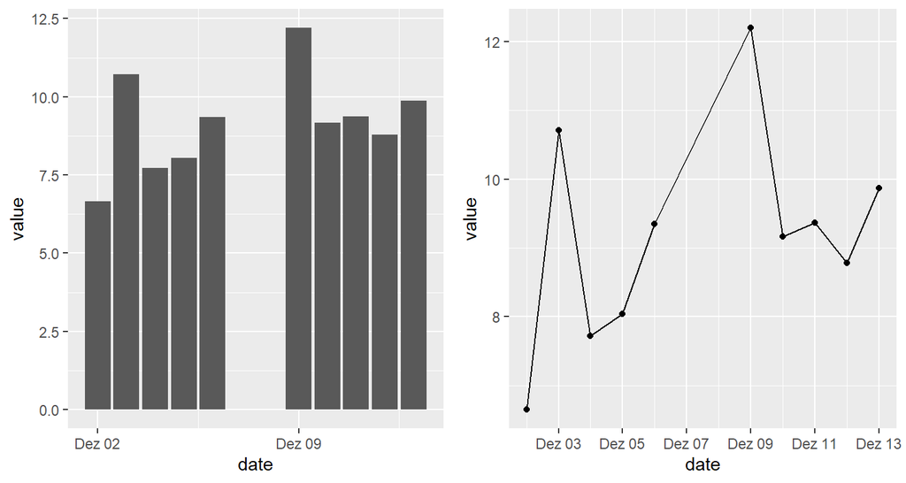

### Removing weekends from line graphs

Having for each x-tick a label: `scale_x_date(date_breaks = "1 days")`

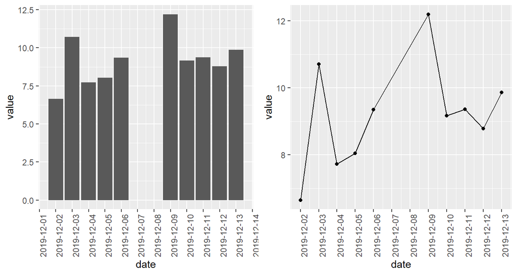

### Removing weekends from line graphs

Casting the `Date` to `factor` or `character` does not work for all geoms.  
And the order may change unexpectingly.

```
## geom_path: Each group consists of only one observation. Do you need to
## adjust the group aesthetic?
```

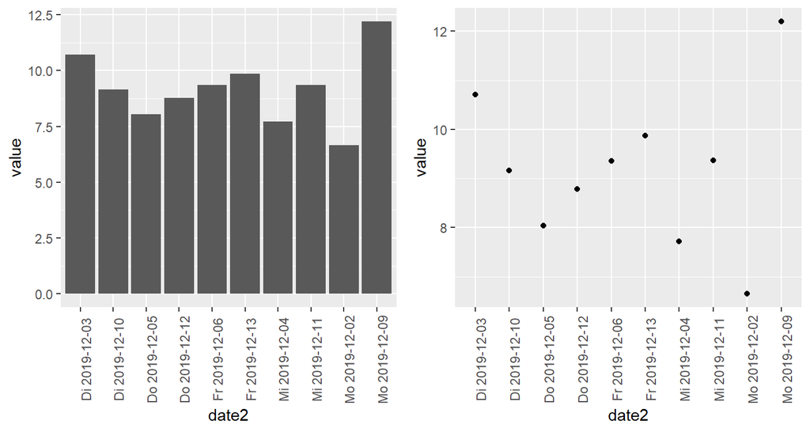

### Removing weekends from line graphs

And this is the trick:

- put weekday at the end of the string -> numbers in the front follow the correct order
- `stat_summary(geom = "line", fun.y = sum)` with `group = 1` in the `aes()`

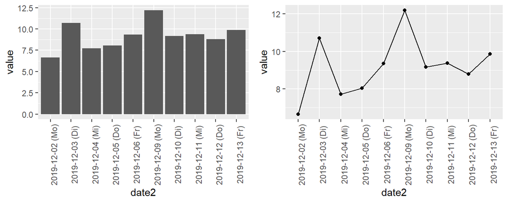

```r
dat2$date2 <- as.character(dat2$date, format = "%Y-%m-%d (%a)")
p2 <- ggplot(data = dat2, aes(x = date2, y = value, group = 1)) +
  stat_summary(geom = "line", fun.y = sum) +
  geom_point() +
  theme(axis.text.x = element_text(angle = 90))
```

## Tip 8: Plots within Plots

### Plots within Plots

Sometimes we want to combine plots since they are related. Typically we plot them in one graph, e.g. with different line types, colors or in subplots using for example `facet_grid()` or `facet_warp()` from `ggplot2`. Another way is to plot them side by side, either in *R* or in *LaTeX*.

Once in a while, you might want to plot a second graph in the first plot.

The following plot and corresponding code I found here:  
https://www.r-bloggers.com/plots-within-plots-with-ggplot2-and-ggmap/

The key function is `annotation_custom()` in the `ggplot2` package.

### Plots within Plots

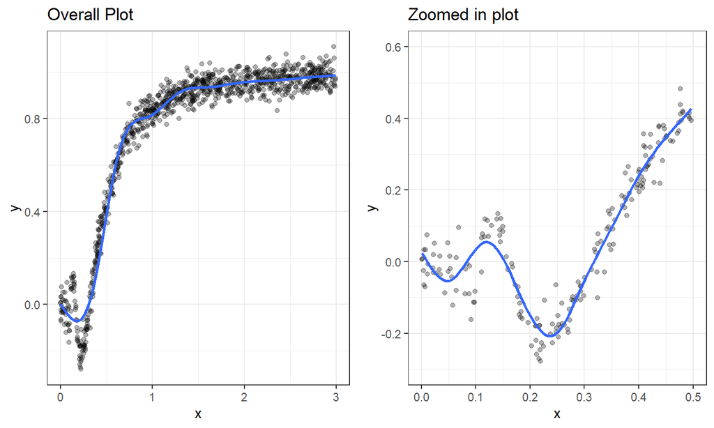

### Plots within Plots

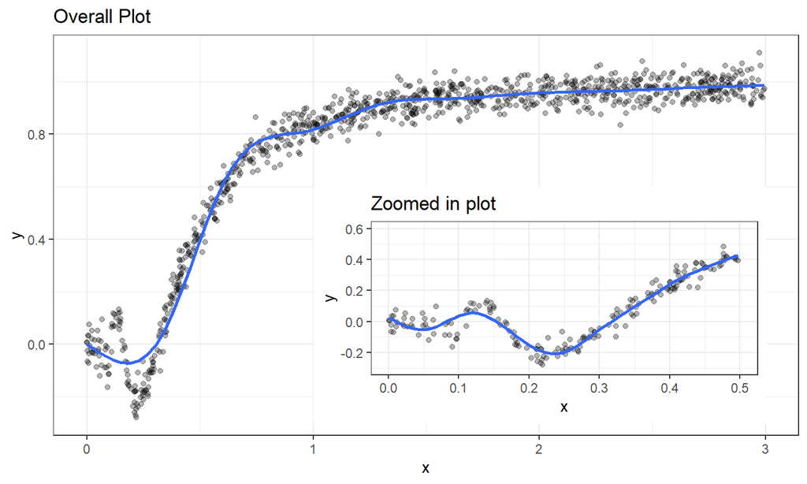

```r
# plot with inset
p1 + annotation_custom(ggplotGrob(p2), xmin = 1, xmax = 3,
ymin = -0.3, ymax = 0.6)
```

### Plots within Plots

With rectangle and “zoom lines”…

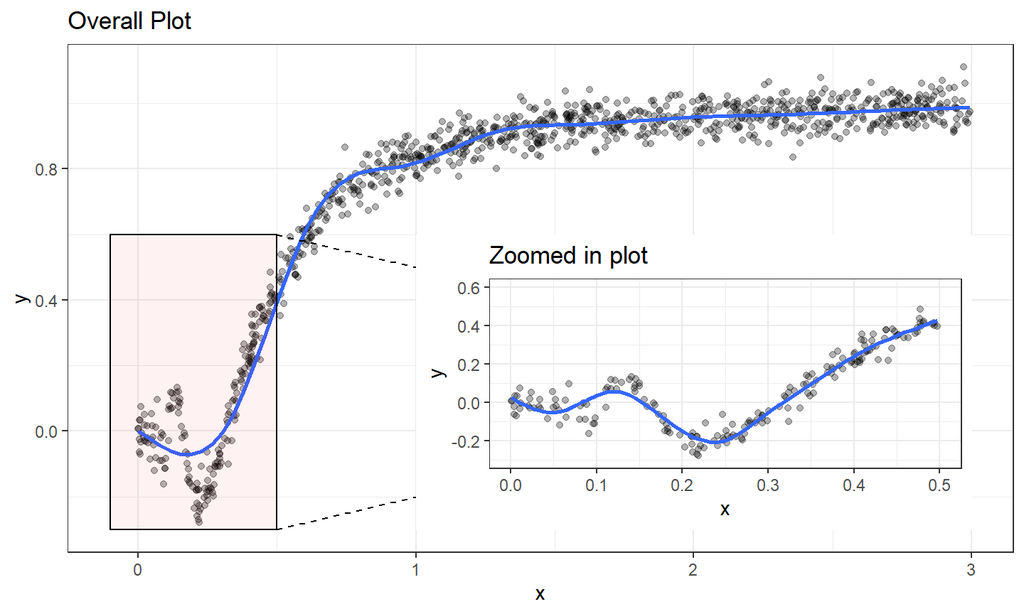

## Tip 9: Two plots in one with different y-axes

### Two plots in one with different y-axes

Typical two time series etc. are plotted side by side, e.g. with `facet_grid()` or `multiplot()`. But sometimes we want to have them in one plot to see “correlations”, save space, …  
Problem: The time series have different scales of y-axes.

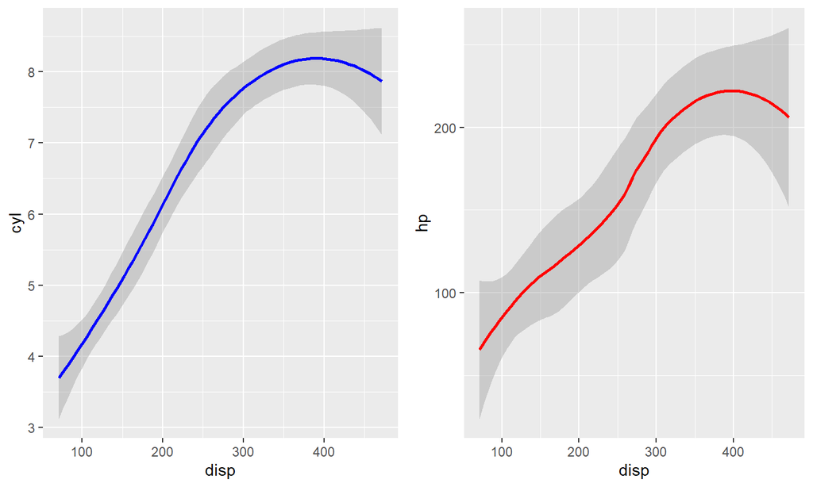

### Two plots in one with different y-axes

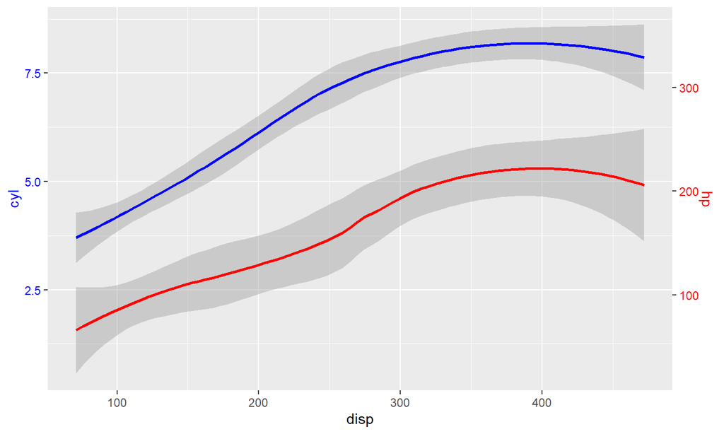

### Two plots in one with different y-axes

```r
scaleFactor <- max(mtcars$cyl) / max(mtcars$hp)

ggplot(mtcars, aes(x=disp)) +
  geom_smooth(aes(y=cyl), method="loess", col="blue") +
  geom_smooth(aes(y=hp * scaleFactor), method="loess", col="red") +
  scale_y_continuous(name="cyl", sec.axis=sec_axis(~./scaleFactor, name="hp")) +
  theme(
    axis.title.y.left=element_text(color="blue"),
    axis.text.y.left=element_text(color="blue"),
    axis.title.y.right=element_text(color="red"),
    axis.text.y.right=element_text(color="red")
  )
```

Found here: https://stackoverflow.com/questions/3099219/plot-with-2-y-axes-one-y-axis-on-the-left-and-another-y-axis-on-the-right/3117319

**Main ideas:**

- Scale the second plot to the scale of the first one
- Second axis `sec.axis=sec_axis(~./scaleFactor, name="hp")`
- Adjust the axis labeling

### Two plots in one with different y-axes - critisism

There is a wide discussion and criticism about plotting plots with separate y scales, saying that such plots are fundamentally flawed.  
Here just a few of the most important criticism points:

- A graph should only include a dual-scaled axis when needed to compare data sets that have **different units of measure**.
- **Magnitude comparisons** between values with **different units of measure and scales** are not appropriate, and should therefore be discouraged.
- Nothing but **lines** should be used to display values in graphs with dual-scaled axes, because only lines focus attention on the **overall pattern** formed by the values and comparisons of those patterns.
- They are **not invertible**.
- They are relatively **hard to read correctly** compared to other options.
- They are **easily manipulated to mislead**.

[Discussion point on stackoverflow](https://stackoverflow.com/a/3101876/) by Hadley Wickham  
[Dual-Scaled Axes in Graphs Are They Ever the Best Solution?](http://www.perceptualedge.com/articles/visual_business_intelligence/dual-scaled_axes.pdf) by Stephen Few

## Thank you!

Many thanks to all the bloggers, R specialists on stackoverview, R enthusiasts, etc.

## Tip 10: Dashboards: Use gauges to visualize single numbers with levels

```r
library(flexdashboard)

gauge(42, min = 0, max = 100, symbol = '%', gaugeSectors(
  success = c(80, 100), warning = c(40, 79), danger = c(0, 39)
))
```

[interactive chart not shown]

## Tip 11: Alternative to gauges: bullet graphs

### Alternative to gauges: bullet graphs

A **bullet graph** is a variation of a bar graph developed by **Stephen Few**. Seemingly inspired by the traditional thermometer charts and progress bars found in many dashboards, the bullet graph serves as a replacement for dashboard gauges and meters. Bullet graphs were developed to overcome the fundamental issues of gauges and meters: they typically display too little information, require too much space, and are cluttered with useless and distracting decoration.

(From Wikipedia https://en.wikipedia.org/wiki/Bullet_graph)

For **R** I found several implementations, e.g.

with base R: https://mtorchiano.wordpress.com/2014/12/20/bullet-graph-an-implementation-in-r/ and the code available at https://github.com/mtorchiano/MTkR/wiki/Bullet-Graph

*d3Dashboard*: https://www.santoshsrinivas.com/bullet-graphs-using-r/

with *ggplot2*: https://github.com/hrbrmstr/Rbulletgraph

with *rAmCharts* using the ‘AmCharts’ Library (JavaScript) on CRAN

### Alternative to gauges: bullet graphs

One possible implementation taken from https://github.com/mtorchiano/MTkR/wiki/Bullet-Graph

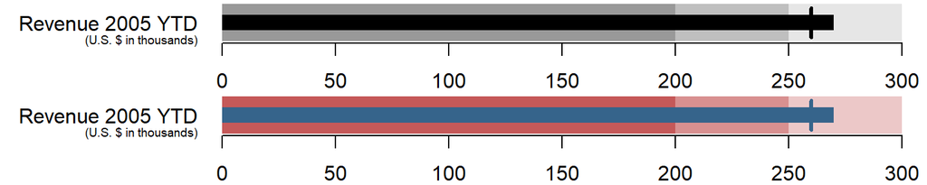

or with d3dashboard:

[interactive chart not shown]